# Lab_8_EvoGeno_BenEarle

Ben Earle

10/25/2020

# Exercises 1

# Exercise 2

### We now take a deeper dive into phylogenetic analysis by learning to use CIPRES. CIPRES is a public resource for inference of large phylogenetic trees.

# Exercise 3 - Visualizing & analyzing phylogenetic trees w/ R + ggtree

## Basic Trees

```r
tree <- read.tree("tree_newick.nwk")
tree
```

```
##
## Phylogenetic tree with 13 tips and 12 internal nodes.
##
## Tip labels:
##   A, B, C, D, E, F, ...
##
## Rooted; includes branch lengths.
```

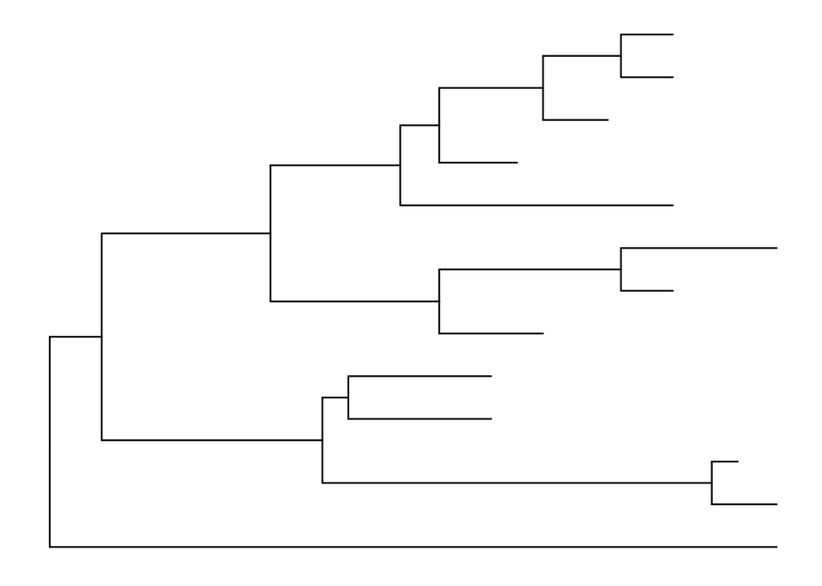

```r
ggtree(tree)
```

### Add a scale

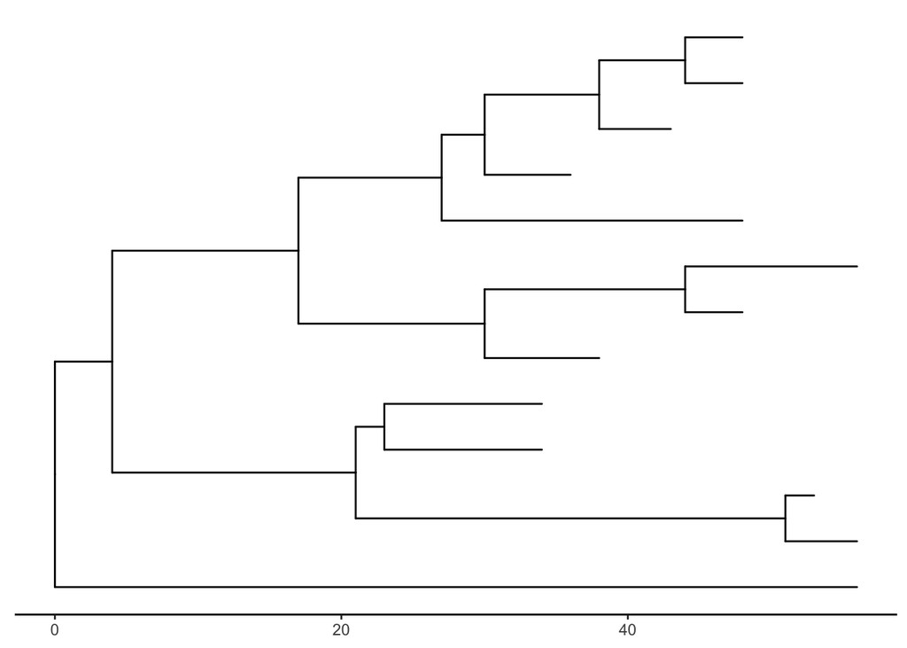

```r
ggtree(tree) + theme_tree2()
```

### The default is to plot a phylogram, where the x-axis shows the genetic change / evolutionary distance. If you want to disable scaling and produce a cladogram instead, set the branch.length=“none” option inside the ggtree()

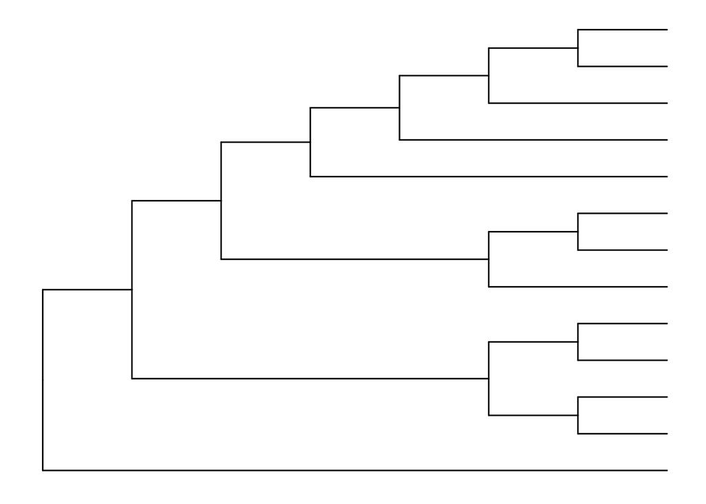

```r
ggtree(tree, branch.length="none")
```

### cladogram (no branch scaling) using thick blue dotted lines

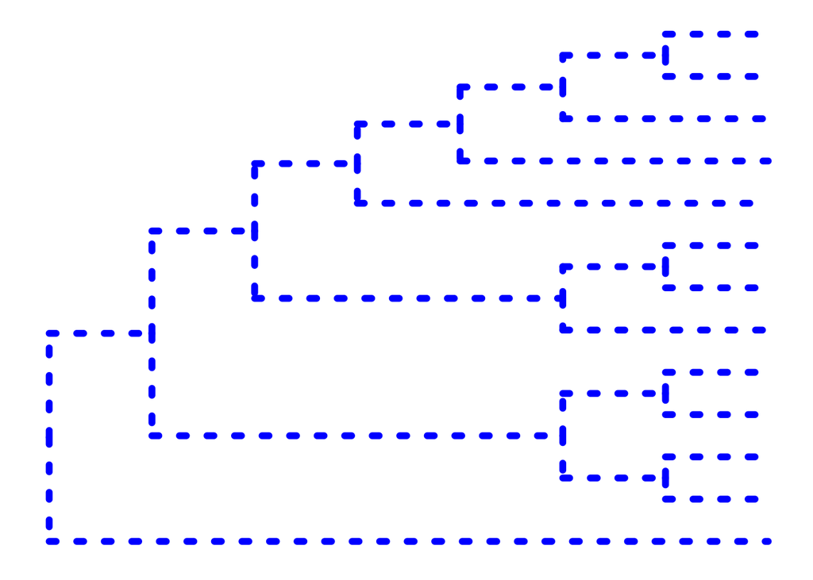

```r
ggtree(tree, branch.length="none", color="blue", size=2, linetype=3)
```

# Exercise 1

## Part 1 - slanted phylogenetic tree

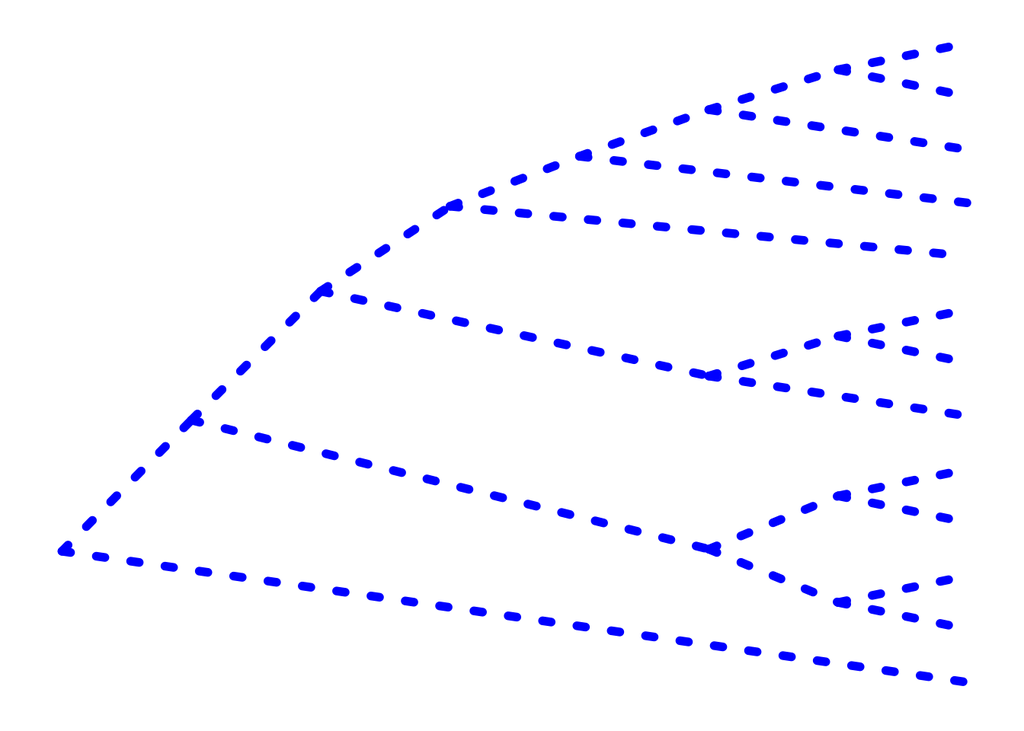

```r
ggtree(tree, branch.length="none", color="blue", size=2, linetype=3, layout = "slanted")
```

## Part 2 - circular phylogenetic tree

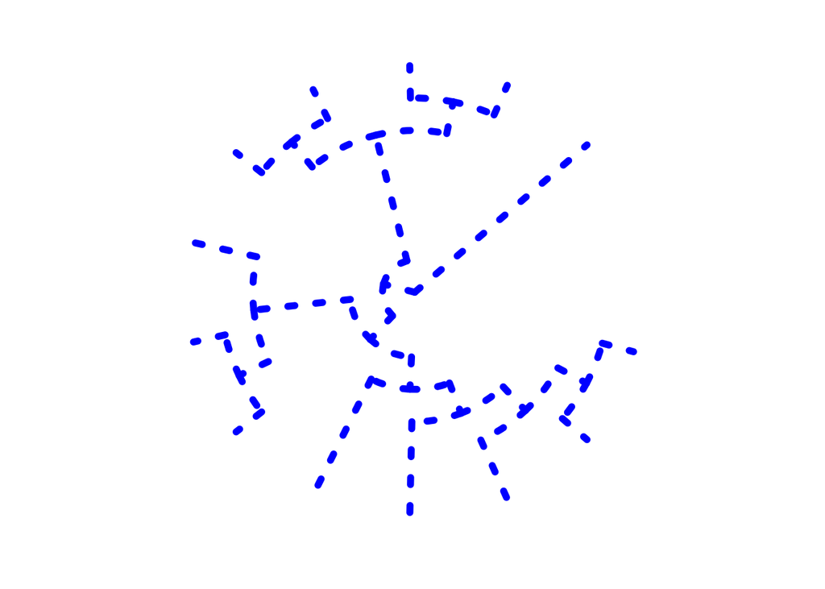

```r
ggtree(tree, branch.length="none", color="blue", size=2, linetype=3, layout = "circular")
```

## Part 3 - circular unscaled claudogram with thick red line

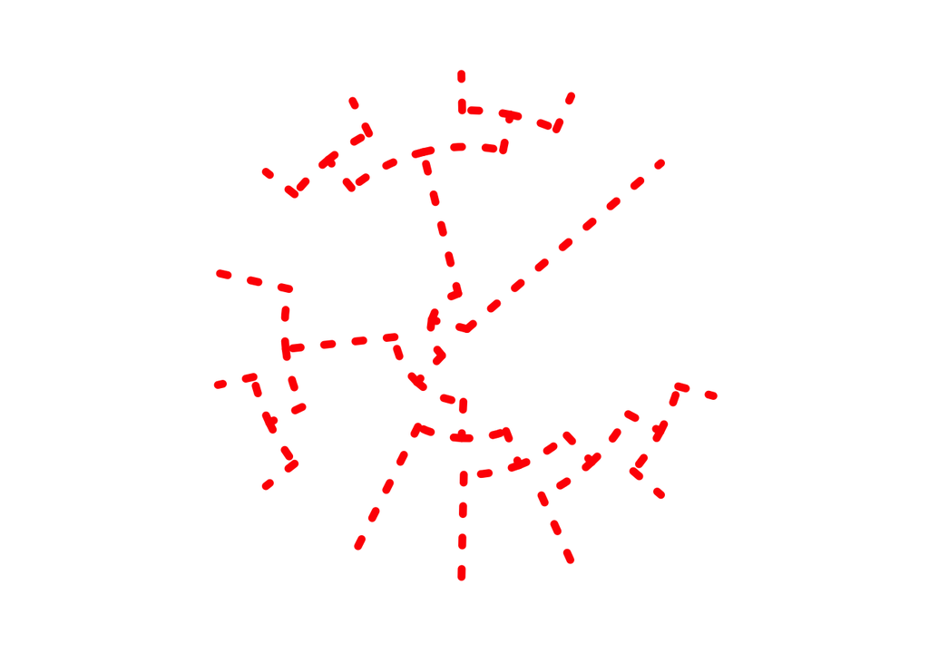

```r
ggtree(tree, branch.length="none", color="red", size=2, linetype=3, layout = "circular")
```

# Other Tree Geoms ###In order to add additional layers, we must first create a plot object, p, to store the basic layout of a ggplot. We will then add node and tip points, then label the tips (all in the same code chunk).

```r
p <- ggtree(tree)
```

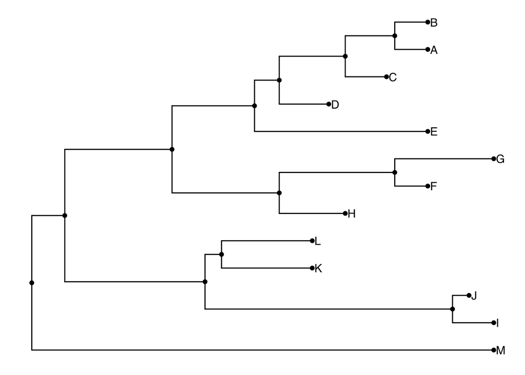

```r
p + geom_nodepoint() +
  geom_tippoint() +
  geom_tiplab()
```

## Exercise 2

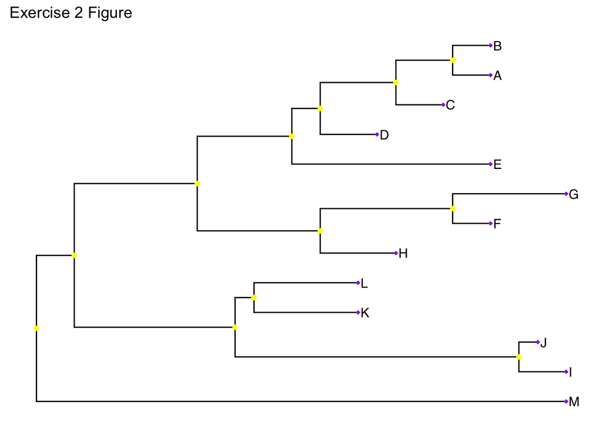

```r
p + geom_nodepoint(color = "yellow", alpha = NA) +
  geom_tippoint(pch = 18, color = "purple") +
  geom_tiplab() +
  ggtitle("Exercise 2 Figure")
```

## Internal node number

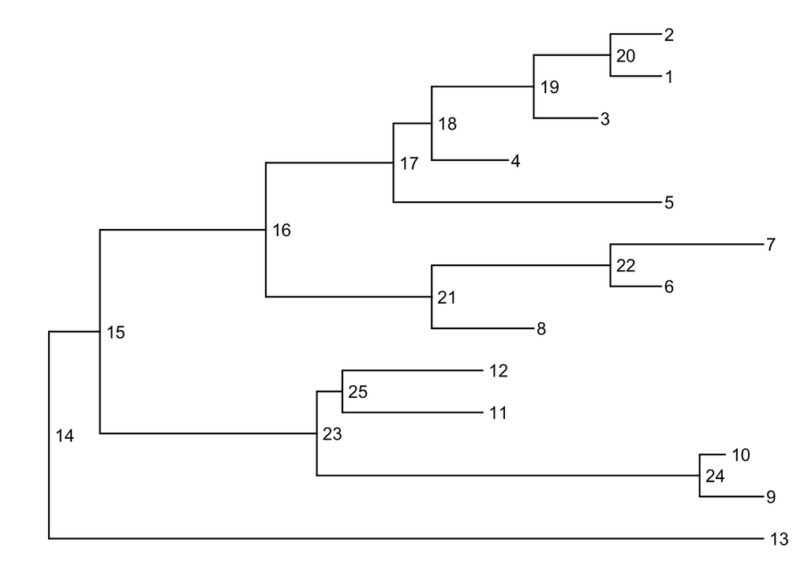

```r
ggtree(tree) + geom_text(aes(label=node), hjust=-.3)
```

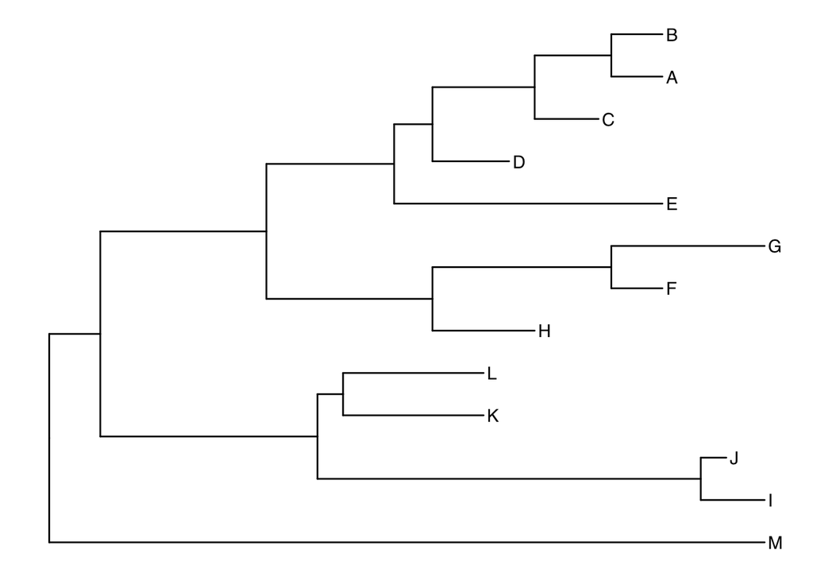

```r
ggtree(tree) + geom_tiplab()
```

```r
MRCA(tree, c("C", "E"))
```

```
## [1] 17
```

```r
MRCA(tree, c("G", "H"))
```

```
## [1] 21
```

```r
# MRCA(tree, tip=c("C", "E"))
# MRCA(tree, tip=c("G", "H"))
```

## Labeling Clades

### We can use geom_cladelabel() to add another geom layer to annotate a selected clade with a bar indicating the clade with a corresponding label. You select the clades using the internal node number for the node that connects all the taxa in that clade.

### Annotation of the Clade with the most recent common ancestor between taxa C and E (internal node 17):

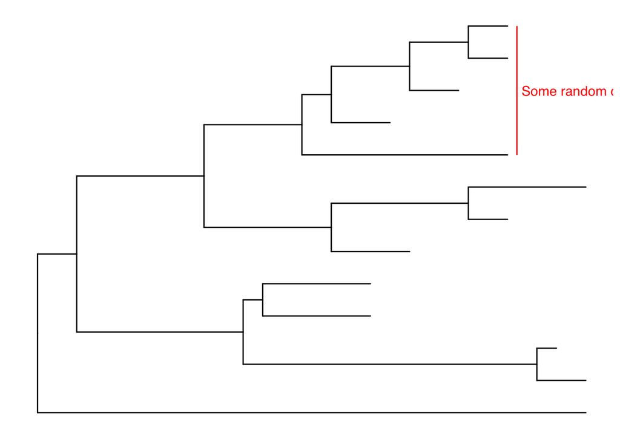

```r
ggtree(tree) +
  geom_cladelabel(node=17, label="Some random clade", color="red")
```

### Adding back the tips

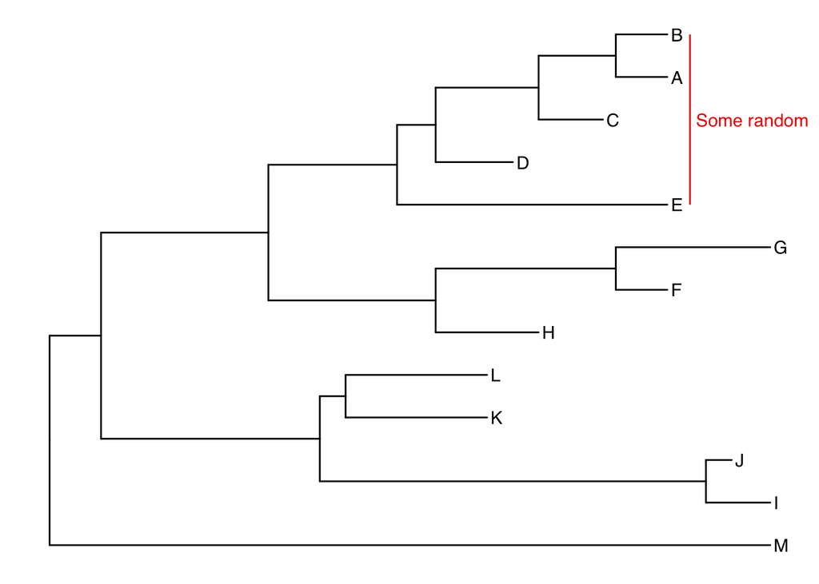

```r
ggtree(tree) +
  geom_tiplab() +
  geom_cladelabel(node=17, label="Some random clade",
                  color="red2", offset=.8)
```

### adding another label for the clade connecting taxa G and H (internal node 21).

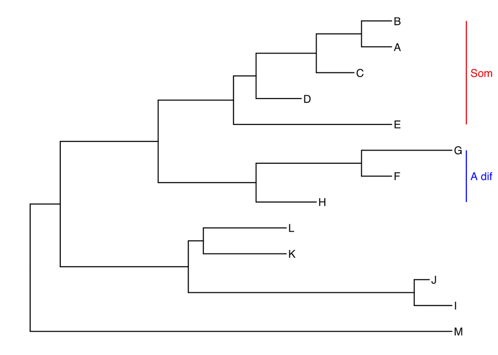

```r
ggtree(tree) +
  geom_tiplab() +
  geom_cladelabel(node=17, label="Some random clade",
                  color="red2", offset=.8, align=TRUE) +
  geom_cladelabel(node=21, label="A different clade",
                  color="blue", offset=.8, align=TRUE)
```

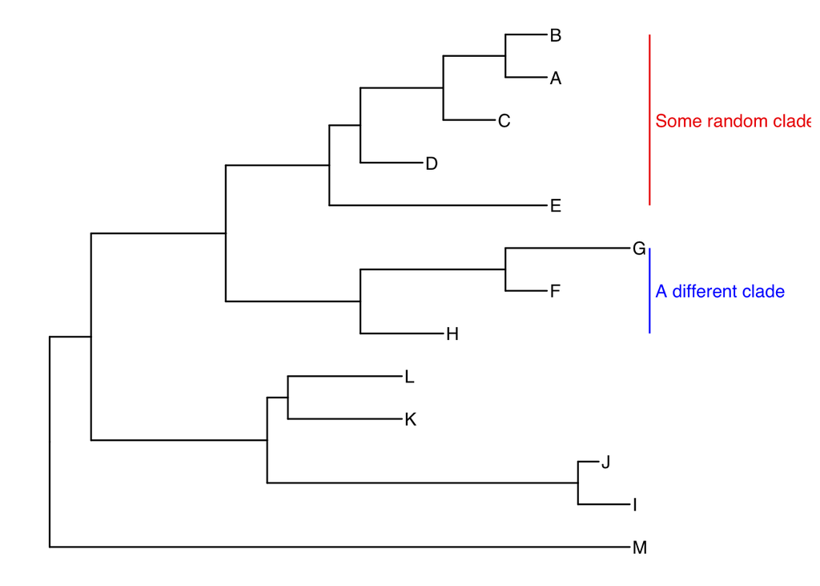

```r
ggtree(tree) +
  geom_tiplab() +
  geom_cladelabel(node=17, label="Some random clade",
                  color="red2", offset=.8, align=TRUE) +
  geom_cladelabel(node=21, label="A different clade",
                  color="blue", offset=.8, align=TRUE) +
  theme_tree2() +
  xlim(0, 70) +
  theme_tree()
```

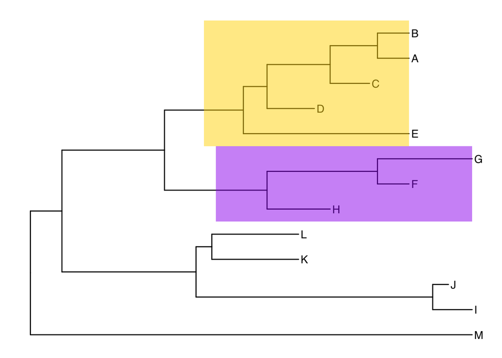

```r
ggtree(tree) +
  geom_tiplab() +
  geom_hilight(node=17, fill="gold") +
  geom_hilight(node=21, fill="purple")
```

## Connecting Taxa

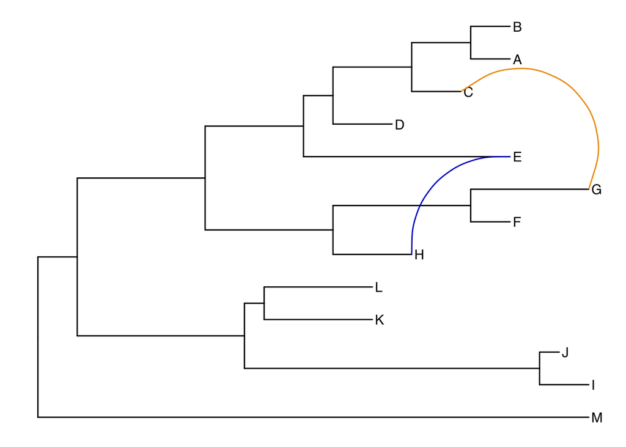

```r
ggtree(tree) +
  geom_tiplab() +
  geom_taxalink("E", "H", color="blue3") +
  geom_taxalink("C", "G", color="orange2", curvature=-.9)
```

## Exercise 3

```r
MRCA(tree, c("B", "C"))
```

```
## [1] 19
```

```r
MRCA(tree, c("L", "J"))
```

```
## [1] 23
```

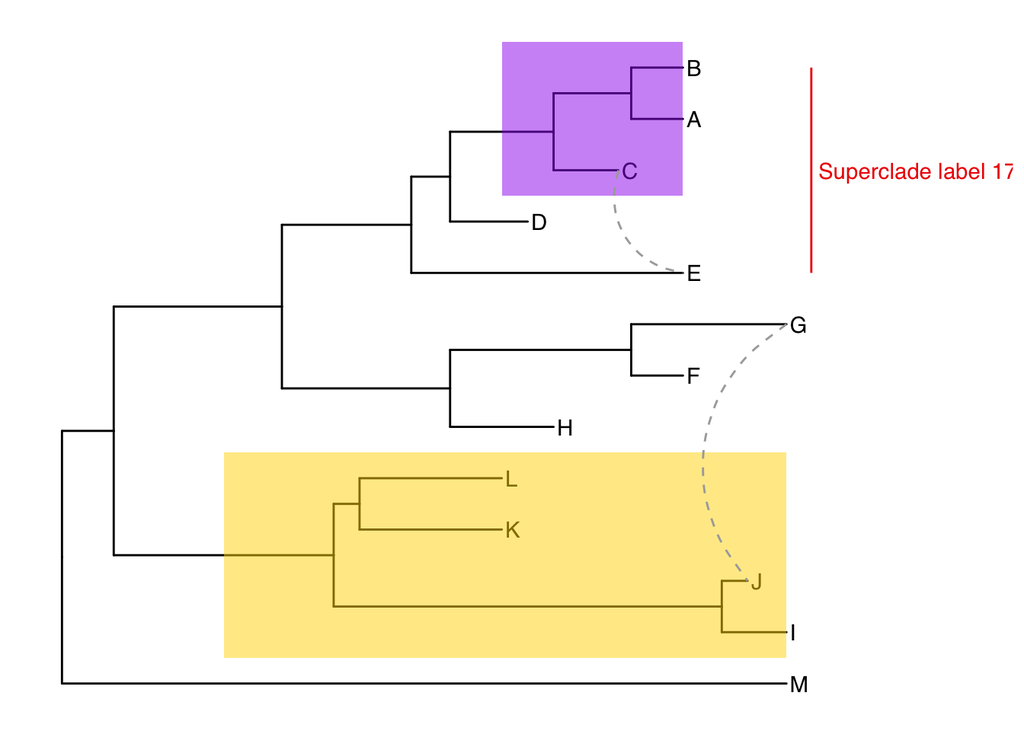

```r
ggtree(tree) +
  geom_tiplab() +
  geom_cladelabel(node=17, label="Superclade label 17",
                  color="red2", offset=.8, align=TRUE) +
  geom_highlight(node=19, fill = "purple") +
  geom_highlight(node=23, fill = "Gold") +
  geom_taxalink("C", "E", linetype=2, color="dark grey") +
  geom_taxalink("G", "J", linetype=2, color="dark grey") +
  theme_tree() +
  xlim(0, 70)
```

# Advanced Tree Annotation

```r
tree <- read.beast("flu_tree_beast.tree")
```

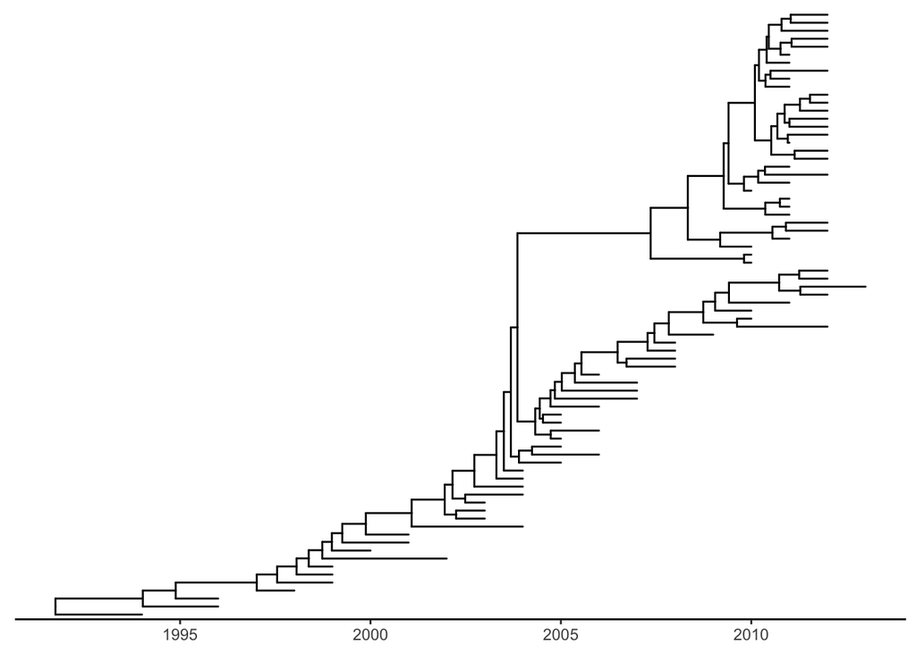

```r
ggtree(tree, mrsd="2013-01-01") +
  theme_tree2()
```

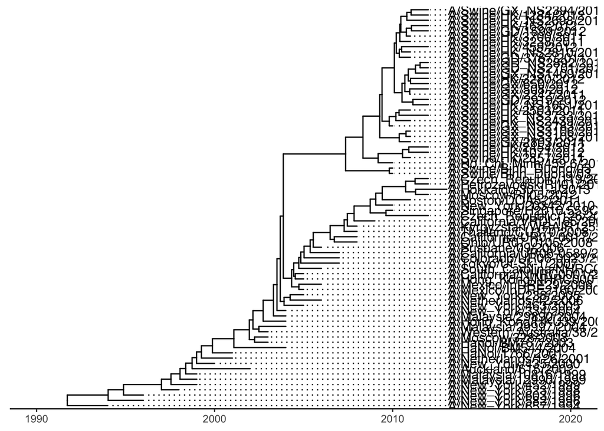

```r
ggtree(tree, mrsd="2013-01-01") +
  theme_tree2() +
  geom_tiplab(align=TRUE, linesize=.5) +
  xlim(1990, 2020)
```

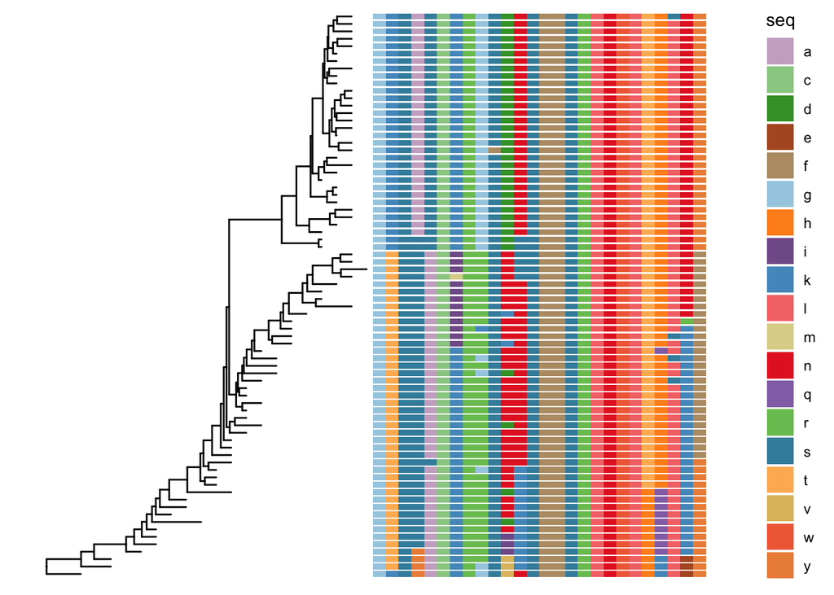

```r
msaplot(p=ggtree(tree), fasta="flu_aasequence.fasta", window=c(150, 175))
```

# Bonus!

## Many Trees

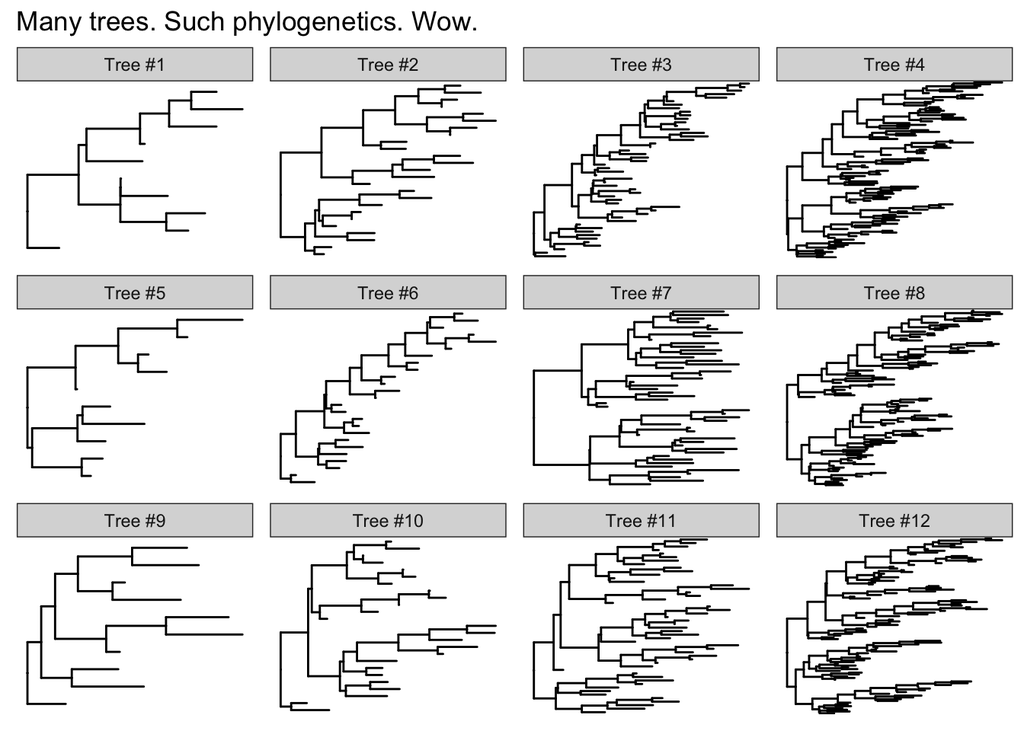

```r
set.seed(42)
trees <- lapply(rep(c(10, 25, 50, 100), 3), rtree)
class(trees) <- "multiPhylo"
ggtree(trees) + facet_wrap(~.id, scale="free", ncol=4) + ggtitle("Many trees. Such phylogenetics. Wow.")
```

## Plot trees with other date

```r
tree <- rtree(30)
```

### Make original plot

```r
p <- ggtree(tree)
```

### generate some random values for each tip label in the data

```r
d1 <- data.frame(id=tree$tip.label, val=rnorm(30, sd=3))
```

### Make a second plot with the original, naming the new plot “dot”,

### using the data you just created, with a point geom.

```r
p2 <- facet_plot(p, panel="dot", data=d1, geom=geom_point, aes(x=val), color='red3')
```

### Make some more data with another random value.

```r
d2 <- data.frame(id=tree$tip.label, value = abs(rnorm(30, mean=100, sd=50)))
```

### Now add to that second plot, this time using the new d2 data above,

### This time showing a bar segment, size 3, colored blue.

```r
p3 <- facet_plot(p2, panel='bar', data=d2, geom=geom_segment,
           aes(x=0, xend=value, y=y, yend=y), size=3, color='blue4')
```

### Show all three plots with a scale

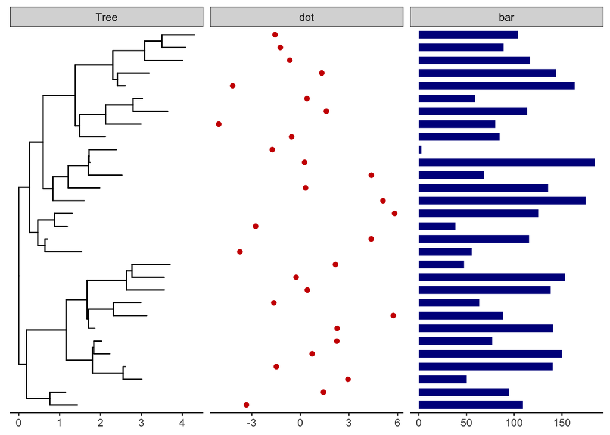

```r
p3 + theme_tree2()
```

# Exercise 4 original exercises

```r
tree <- read.tree("fastree_result.tre")
tree
```

```
##
## Phylogenetic tree with 21 tips and 19 internal nodes.
##
## Tip labels:
##   Nanoarchaeum_equitans, Pyrococcus_abyssi, Methanocaldococcus_jannaschii, Thermoplasma_volcanium, Halalkalicoccus_jeotgali, Archaeoglobus_fulgidus, ...
## Node labels:
##   , 0.998, 0.968, 0.997, 0.818, 1.000, ...
##
## Unrooted; includes branch lengths.
```

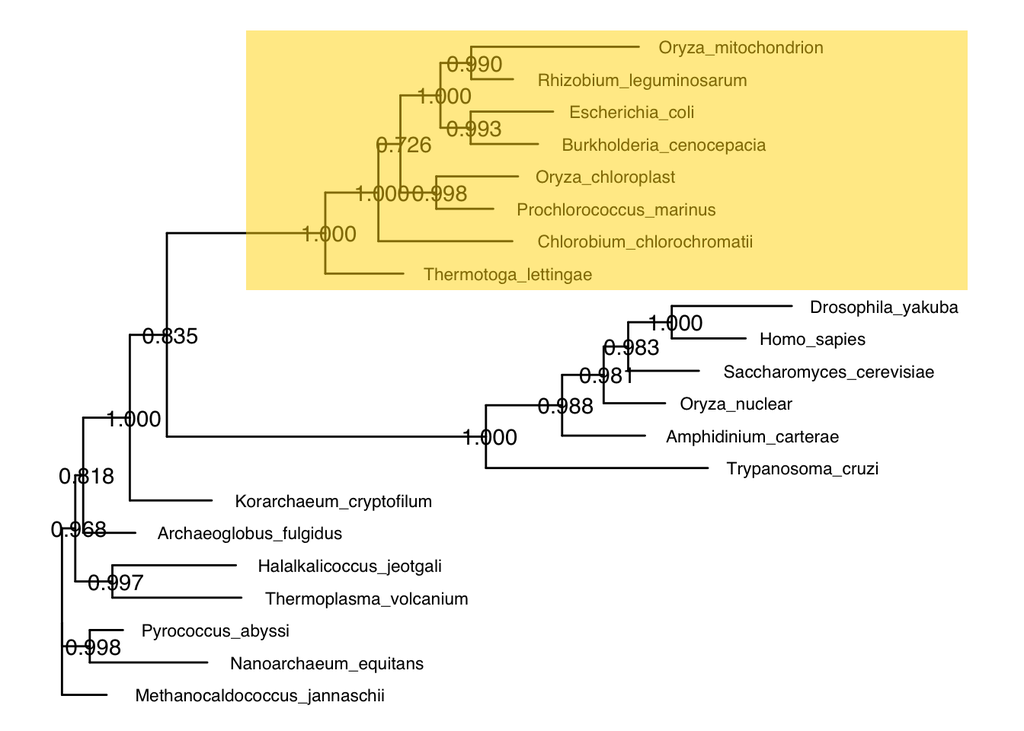

```r
ggtree(tree) +
  geom_nodelab() +
  geom_tiplab(hjust=-.1, size = 3) +
  geom_hilight(node=34, fill="gold", extend = 0.5)
```

## References

title: “Evolutionary Genomics & Bioinformatics” author: “Jeffrey Blanchard” date: “2/26/2020” output: html_document bibliography: data/references.bib

title: “Visualizing and Annotating Phylogenetic Trees with R+ggtree” Author: “Stephen Turner” output: html_document bibliography: https://4va.github.io/biodatasci/r-ggtree.html

title: “ggtree: an R package for visualization and annotation of phylogenetic trees with their covariates and other associated data” author: “Guangchuang Yu, David Smith, Huachen Zhu, Yi Guan, Tommy Tsan-Yuk Lam” date: “2017” output: html_document bibliography: https://doi.org/10.1093/molbev/msy194

title: “Expansion of genotypic diversity and establishment of 2009 H1N1 pandemic-origin internal genes in pigs in China.” author: “Huey Liang” date: “September 2014” output: html_document bibliography:https://www.ncbi.nlm.nih.gov/pmc/articles/PMC4178866/